# MIS_Pronos_Class_14_Feb_Suavizamiento_Simple_y_Ponderado_Demanda_electrico

Sergibar

2023-02-14

# Materia: Pronosticos

# Dr. Jair Morales C.

## Alumno: Ibarra Raramírez Sergio (414025796)

## Fecha: Feb.2023

## Suavizamiento mediante media movil

Comenzaremos instalando las liberias necesarias para el desarrollo

```r
library(pracma)
```

```r
library(tidyverse)      # data manipulation and visualization
library(lubridate)      # easily work with dates and times
library(fpp2)           # working with time series data
library(zoo)
```

```r
library(ggplot2)
library(plyr)
library(dplyr)
library(knitr)
library(TTR)
```

Vamos a importar el documento csv que contiene la demanda de gas natural en el sector eléctrico Mexicano (Si se importa el archivo full1 incluirá las columnas de date & demanded_gas)

```r
#URL desktop dell
#Demanda_electricoA <-read.csv("C:\\Users\\Sergio\\Documents\\MIS\\Second_semester\\Pronosticos_UNAM\\pronosticos_UNAM_git\\pronosticos_UNAM_gitHub\\Demanda_electrico_2022_full1.csv", header= TRUE)

#URL HPi3
Demanda_electricoA <-read.csv("C:\\Users\\sergi\\OneDrive\\Documentos\\MIS_UNAM\\Segundo_semestre\\Pronosticos_UNAM_HPi3\\pronosticos_UNAM_git\\Demanda_electrico_2022_full1.csv", header= TRUE)
```

Comprobemos que el documento Demanda_electrico se haya importado correctamente

```r
head(Demanda_electricoA)
```

```
##       Date Demanded_Gas
## 1 1/1/2005      1819.58
## 2 2/1/2005      1895.33
## 3 3/1/2005      1765.86
## 4 4/1/2005      1642.70
## 5 5/1/2005      1895.54
## 6 6/1/2005      2051.72
```

```r
summary(Demanda_electricoA)
```

```
##      Date            Demanded_Gas
##  Length:213         Min.   :1561
##  Class :character   1st Qu.:2600
##  Mode  :character   Median :3016
##                     Mean   :3038
##                     3rd Qu.:3403
##                     Max.   :5168
```

```r
typeof(Demanda_electricoA)
```

```
## [1] "list"
```

```r
dim(Demanda_electricoA)
```

```
## [1] 213   2
```

```r
Demanda_electricoA$as.date = as.Date(Demanda_electricoA$Date, format = "%m/%d/%Y")
head(Demanda_electricoA)
```

```
##       Date Demanded_Gas    as.date
## 1 1/1/2005      1819.58 2005-01-01
## 2 2/1/2005      1895.33 2005-02-01
## 3 3/1/2005      1765.86 2005-03-01
## 4 4/1/2005      1642.70 2005-04-01
## 5 5/1/2005      1895.54 2005-05-01
## 6 6/1/2005      2051.72 2005-06-01
```

```r
tail(Demanda_electricoA)
```

```
##         Date Demanded_Gas    as.date
## 208 4/1/2022      3403.44 2022-04-01
## 209 5/1/2022      3350.03 2022-05-01
## 210 6/1/2022      3498.70 2022-06-01
## 211 7/1/2022      3350.97 2022-07-01
## 212 8/1/2022      3506.42 2022-08-01
## 213 9/1/2022      3778.37 2022-09-01
```

```r
typeof(Demanda_electricoA)
```

```
## [1] "list"
```

```r
dim(Demanda_electricoA)
```

```
## [1] 213   3
```

Guardemos en variables los días min y max para poder usar en funcion ts

```r
typeof(Demanda_electricoA$as.date)
```

```
## [1] "double"
```

```r
min_date = min(Demanda_electricoA$as.date, na.rm = T)
min_date
```

```
## [1] "2005-01-01"
```

```r
max_date =max(Demanda_electricoA$as.date, na.rm = T)
max_date
```

```
## [1] "2022-09-01"
```

```r
min_demanded_gas = min((Demanda_electricoA[, "Demanded_Gas"]), na.rm = T)
min_demanded_gas
```

```
## [1] 1560.98
```

Usemos la funcion ts. de R para “hacer los datos de nuestra serie” un dato “tipo serie en R” En este caso de manera específca la columna de Demanded_gas

```r
Demanda_electricoA.ts<- ts(Demanda_electricoA$Demanded_Gas, frequency = 12, start =c(2005,1), end =c(2022,8))
head(Demanda_electricoA.ts)
```

```
##          Jan     Feb     Mar     Apr     May     Jun
## 2005 1819.58 1895.33 1765.86 1642.70 1895.54 2051.72
```

```r
typeof(Demanda_electricoA.ts)
```

```
## [1] "double"
```

```r
dim(Demanda_electricoA.ts)
```

Grafica de la serie “ajustada a serie de tiempo”

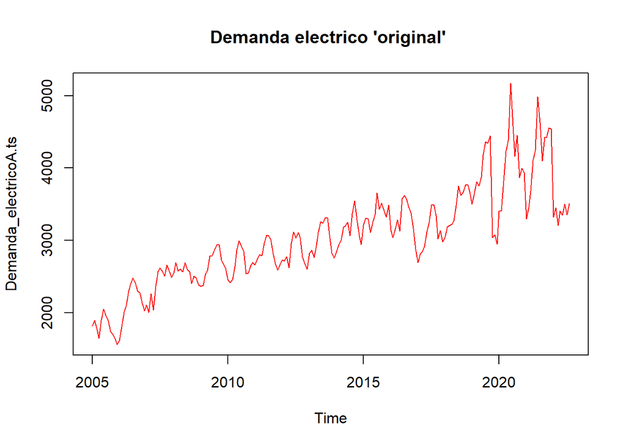

```r
plot(Demanda_electricoA.ts, col = "red", main = "Demanda electrico 'original' ")
```

Agregando “suavizamiento con Moving Average usado la libreria forecast” -MA orden 3 y centrado-

```r
library(forecast)
MA_m3_center <- forecast::ma(Demanda_electricoA.ts, order=3, centre = TRUE)
MA_m3_center
```

```
##           Jan      Feb      Mar      Apr      May      Jun      Jul      Aug
## 2005       NA 1826.923 1767.963 1768.033 1863.320 1969.770 1967.810 1863.603
## 2006 1659.253 1807.887 1973.840 2138.030 2268.697 2392.800 2430.860 2397.397
## 2007 2047.213 2124.893 2100.817 2219.140 2321.873 2515.810 2588.333 2568.203
## 2008 2577.370 2606.143 2623.453 2579.627 2617.590 2617.027 2616.680 2521.760
## 2009 2375.063 2425.990 2499.750 2634.783 2718.110 2811.667 2863.910 2916.053
## 2010 2494.277 2442.580 2506.487 2656.150 2833.330 2924.447 2918.500 2768.170
## 2011 2698.033 2735.643 2777.317 2851.770 2942.137 3034.780 3051.927 2968.007
## 2012 2703.407 2739.190 2701.510 2782.707 2898.017 3036.657 3087.083 3059.950
## 2013 2763.723 2816.600 2839.767 2922.417 3088.263 3203.510 3271.030 3286.593
## 2014 2843.130 2922.590 3037.547 3126.867 3210.500 3171.267 3227.603 3327.173
## 2015 3154.987 3273.707 3238.957 3220.087 3240.710 3423.610 3483.117 3535.117
## 2016 3223.383 3110.203 3156.713 3187.897 3329.473 3440.040 3588.673 3551.867
## 2017 2795.420 2781.533 2855.893 2957.087 3095.667 3288.060 3412.300 3440.877
## 2018 3070.637 3143.890 3204.243 3232.073 3324.180 3500.370 3617.163 3678.713
```

[output cut: 23 more lines]

```r
typeof(MA_m3_center)
```

```
## [1] "double"
```

```r
dim(MA_m3_center)
```

Ploteando la serie original vs MA_m3_center

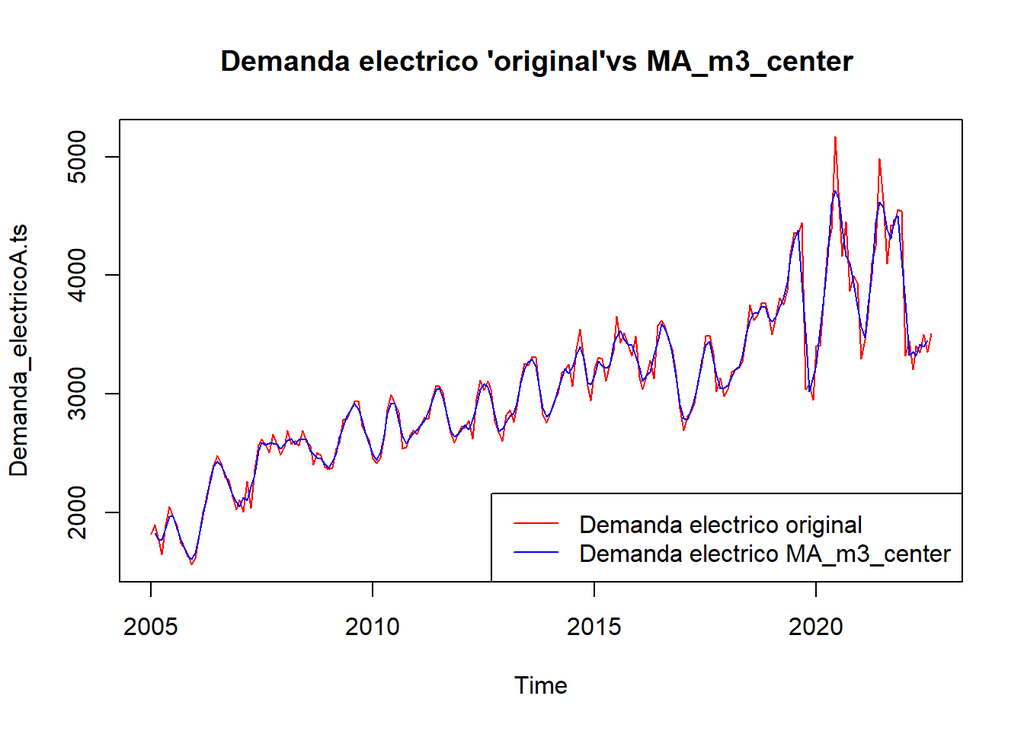

```r
plot(Demanda_electricoA.ts, col = "red", main = "Demanda electrico 'original'vs MA_m3_center ")
lines(MA_m3_center, col="blue")
legend("bottomright", legend = c("Demanda electrico original", "Demanda electrico MA_m3_center"), col = c("red", "blue"), lty = 1)
```

```r
movavg <- function(x, n, type=c("s", "t", "w", "m", "e", "r")) {
    stopifnot(is.numeric(x), is.numeric(n), is.character(type))
    if (length(n) != 1 || ceiling(n != floor(n)) || n <= 1)
        stop("Window length 'n' must be a single integer greater 1.")
    nx <- length(x)
    if (n >= nx)
        stop("Window length 'n' must be greater then length of time series.")
    y <- numeric(nx)

    type <- match.arg(type)
    if (type == "s") {         # simple
        for (k in 1:(n-1))  y[k] <- mean(x[1:k])
        for (k in n:nx)     y[k] <- mean(x[(k-n+1):k])

    } else if (type == "t") {  # triangular
        n <- ceiling((n + 1)/2)
        s <- movavg(x, n, "s")
        y <- movavg(s, n, "s")

    } else if (type == "w") {  # weighted
        for (k in 1:(n-1))  y[k] <- 2 * sum((k:1)*x[k:1]) / (k*(k+1))
        for (k in n:nx)     y[k] <- 2 * sum((n:1)*x[k:(k-n+1)]) / (n*(n+1))

    } else if (type == "m") {  # modified
        y[1] <- x[1]
        for (k in 2:nx)     y[k] <- y[k-1] + (x[k] - y[k-1])/n

    } else if (type == "e") {  # exponential
        a <- 2/(n+1)
        y[1] <- x[1]
        for (k in 2:nx)     y[k] <- a*x[k] + (1-a)*y[k-1]

    } else if (type == "r") {  # running
        a <- 1/n
        y[1] <- x[1]
        for (k in 2:nx)     y[k] <- a*x[k] + (1-a)*y[k-1]

    } else
        stop("The type must be one of 's', 't', 'w', 'm', 'e', or 'r'.")

    return(y)
}
```

Agregando “suavizamiento con Moving Average usado la función movavg”-MA orden 3 y NO centrado- (En la función movavg se toman en cuenta solo los valores pasados y no los “futuros” es coo SI NO estuvierra centrado el cálculo)

```r
library(forecast)
MA_m3_NOcenter <- movavg(Demanda_electricoA.ts, n=3, type="s")
MA_m3_NOcenter
```

```
##   [1] 1819.580 1857.455 1826.923 1767.963 1768.033 1863.320 1969.770 1967.810
##   [9] 1863.603 1774.893 1694.657 1635.283 1606.793 1659.253 1807.887 1973.840
##  [17] 2138.030 2268.697 2392.800 2430.860 2397.397 2328.493 2235.603 2144.767
##  [25] 2089.747 2047.213 2124.893 2100.817 2219.140 2321.873 2515.810 2588.333
##  [33] 2568.203 2581.140 2580.680 2574.867 2538.563 2577.370 2606.143 2623.453
##  [41] 2579.627 2617.590 2617.027 2616.680 2521.760 2490.163 2463.850 2456.877
##  [49] 2410.300 2375.063 2425.990 2499.750 2634.783 2718.110 2811.667 2863.910
##  [57] 2916.053 2871.890 2785.227 2675.950 2582.173 2494.277 2442.580 2506.487
##  [65] 2656.150 2833.330 2924.447 2918.500 2768.170 2646.377 2582.613 2632.373
##  [73] 2669.343 2698.033 2735.643 2777.317 2851.770 2942.137 3034.780 3051.927
##  [81] 2968.007 2836.370 2694.827 2642.607 2663.117 2703.407 2739.190 2701.510
##  [89] 2782.707 2898.017 3036.657 3087.083 3059.950 2970.403 2828.600 2683.707
##  [97] 2702.680 2763.723 2816.600 2839.767 2922.417 3088.263 3203.510 3271.030
## [105] 3286.593 3233.470 3070.137 2887.967 2807.193 2843.130 2922.590 3037.547
## [113] 3126.867 3210.500 3171.267 3227.603 3327.173 3400.543 3301.473 3099.280
## [121] 3075.847 3154.987 3273.707 3238.957 3220.087 3240.710 3423.610 3483.117
## [129] 3535.117 3454.743 3418.697 3410.623 3319.207 3223.383 3110.203 3156.713
## [137] 3187.897 3329.473 3440.040 3588.673 3551.867 3474.243 3337.993 3142.923
## [145] 2912.740 2795.420 2781.533 2855.893 2957.087 3095.667 3288.060 3412.300
## [153] 3440.877 3282.873 3164.083 3045.397 3053.490 3070.637 3143.890 3204.243
## [161] 3232.073 3324.180 3500.370 3617.163 3678.713 3683.580 3734.093 3738.117
## [169] 3649.580 3608.030 3651.797 3735.270 3811.563 3937.247 4141.070 4296.780
## [177] 4383.617 3942.107 3519.777 3020.383 3142.060 3250.677 3541.413 3819.007
## [185] 4147.487 4597.143 4712.723 4638.010 4399.123 4161.717 4105.840 3935.677
## [193] 3745.230 3564.587 3477.980 3746.777 4010.017 4444.760 4620.437 4572.063
## [201] 4385.017 4313.570 4466.420 4504.587 4139.000 3769.813 3325.837 3353.400
## [209] 3320.143 3417.390 3399.900 3452.030
```

```r
typeof(MA_m3_NOcenter)
```

```
## [1] "double"
```

```r
dim(MA_m3_center)
```

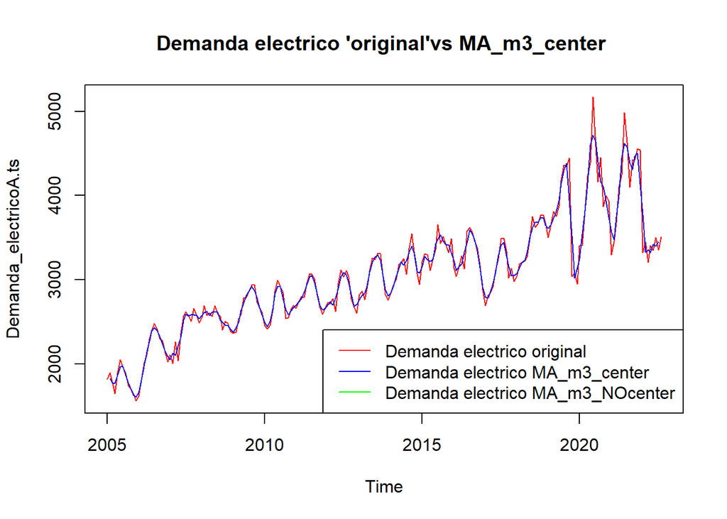

```r
plot(Demanda_electricoA.ts, col = "red", main = "Demanda electrico 'original'vs MA_m3_center ")
lines(MA_m3_center, col="blue")
lines(MA_m3_NOcenter, col="green")
legend("bottomright", legend = c("Demanda electrico original", "Demanda electrico MA_m3_center", "Demanda electrico MA_m3_NOcenter"), col = c("red", "blue", "green"), lty = 1)
```

Ahora recordemos que hemos estado teniendo porblemas para “fusionar” la “list” Demanda_electrico_importado y los double MA_3_Center &MA_3_Center_NOcenter pues indicaba el error que la data era de 213 rows y lo que queramos incluir era de 2012. Entonces usams una “especie de placeholder” que indique que si no tiene un valor le ponga NA y asi poder “igualar la dim” de los “objetos a unir”

Intentemos transformar MA_3_Center a una con un placeholder

```r
MA_m3_center_placeholder <- c(MA_m3_center, NA)
MA_m3_center_placeholder
```

```
##   [1]       NA 1826.923 1767.963 1768.033 1863.320 1969.770 1967.810 1863.603
##   [9] 1774.893 1694.657 1635.283 1606.793 1659.253 1807.887 1973.840 2138.030
##  [17] 2268.697 2392.800 2430.860 2397.397 2328.493 2235.603 2144.767 2089.747
##  [25] 2047.213 2124.893 2100.817 2219.140 2321.873 2515.810 2588.333 2568.203
##  [33] 2581.140 2580.680 2574.867 2538.563 2577.370 2606.143 2623.453 2579.627
##  [41] 2617.590 2617.027 2616.680 2521.760 2490.163 2463.850 2456.877 2410.300
##  [49] 2375.063 2425.990 2499.750 2634.783 2718.110 2811.667 2863.910 2916.053
##  [57] 2871.890 2785.227 2675.950 2582.173 2494.277 2442.580 2506.487 2656.150
##  [65] 2833.330 2924.447 2918.500 2768.170 2646.377 2582.613 2632.373 2669.343
##  [73] 2698.033 2735.643 2777.317 2851.770 2942.137 3034.780 3051.927 2968.007
##  [81] 2836.370 2694.827 2642.607 2663.117 2703.407 2739.190 2701.510 2782.707
##  [89] 2898.017 3036.657 3087.083 3059.950 2970.403 2828.600 2683.707 2702.680
##  [97] 2763.723 2816.600 2839.767 2922.417 3088.263 3203.510 3271.030 3286.593
## [105] 3233.470 3070.137 2887.967 2807.193 2843.130 2922.590 3037.547 3126.867
## [113] 3210.500 3171.267 3227.603 3327.173 3400.543 3301.473 3099.280 3075.847
## [121] 3154.987 3273.707 3238.957 3220.087 3240.710 3423.610 3483.117 3535.117
## [129] 3454.743 3418.697 3410.623 3319.207 3223.383 3110.203 3156.713 3187.897
## [137] 3329.473 3440.040 3588.673 3551.867 3474.243 3337.993 3142.923 2912.740
## [145] 2795.420 2781.533 2855.893 2957.087 3095.667 3288.060 3412.300 3440.877
## [153] 3282.873 3164.083 3045.397 3053.490 3070.637 3143.890 3204.243 3232.073
## [161] 3324.180 3500.370 3617.163 3678.713 3683.580 3734.093 3738.117 3649.580
## [169] 3608.030 3651.797 3735.270 3811.563 3937.247 4141.070 4296.780 4383.617
## [177] 3942.107 3519.777 3020.383 3142.060 3250.677 3541.413 3819.007 4147.487
## [185] 4597.143 4712.723 4638.010 4399.123 4161.717 4105.840 3935.677 3745.230
## [193] 3564.587 3477.980 3746.777 4010.017 4444.760 4620.437 4572.063 4385.017
## [201] 4313.570 4466.420 4504.587 4139.000 3769.813 3325.837 3353.400 3320.143
## [209] 3417.390 3399.900 3452.030       NA       NA
```

Intentemos transformar MA_3_Center_NOcenter a una con un placeholder

```r
MA_m3_NOcenter_placeholder <- c(MA_m3_NOcenter, NA)
MA_m3_NOcenter_placeholder
```

```
##   [1] 1819.580 1857.455 1826.923 1767.963 1768.033 1863.320 1969.770 1967.810
##   [9] 1863.603 1774.893 1694.657 1635.283 1606.793 1659.253 1807.887 1973.840
##  [17] 2138.030 2268.697 2392.800 2430.860 2397.397 2328.493 2235.603 2144.767
##  [25] 2089.747 2047.213 2124.893 2100.817 2219.140 2321.873 2515.810 2588.333
##  [33] 2568.203 2581.140 2580.680 2574.867 2538.563 2577.370 2606.143 2623.453
##  [41] 2579.627 2617.590 2617.027 2616.680 2521.760 2490.163 2463.850 2456.877
##  [49] 2410.300 2375.063 2425.990 2499.750 2634.783 2718.110 2811.667 2863.910
##  [57] 2916.053 2871.890 2785.227 2675.950 2582.173 2494.277 2442.580 2506.487
##  [65] 2656.150 2833.330 2924.447 2918.500 2768.170 2646.377 2582.613 2632.373
##  [73] 2669.343 2698.033 2735.643 2777.317 2851.770 2942.137 3034.780 3051.927
##  [81] 2968.007 2836.370 2694.827 2642.607 2663.117 2703.407 2739.190 2701.510
##  [89] 2782.707 2898.017 3036.657 3087.083 3059.950 2970.403 2828.600 2683.707
##  [97] 2702.680 2763.723 2816.600 2839.767 2922.417 3088.263 3203.510 3271.030
## [105] 3286.593 3233.470 3070.137 2887.967 2807.193 2843.130 2922.590 3037.547
## [113] 3126.867 3210.500 3171.267 3227.603 3327.173 3400.543 3301.473 3099.280
## [121] 3075.847 3154.987 3273.707 3238.957 3220.087 3240.710 3423.610 3483.117
## [129] 3535.117 3454.743 3418.697 3410.623 3319.207 3223.383 3110.203 3156.713
## [137] 3187.897 3329.473 3440.040 3588.673 3551.867 3474.243 3337.993 3142.923
## [145] 2912.740 2795.420 2781.533 2855.893 2957.087 3095.667 3288.060 3412.300
## [153] 3440.877 3282.873 3164.083 3045.397 3053.490 3070.637 3143.890 3204.243
## [161] 3232.073 3324.180 3500.370 3617.163 3678.713 3683.580 3734.093 3738.117
## [169] 3649.580 3608.030 3651.797 3735.270 3811.563 3937.247 4141.070 4296.780
## [177] 4383.617 3942.107 3519.777 3020.383 3142.060 3250.677 3541.413 3819.007
## [185] 4147.487 4597.143 4712.723 4638.010 4399.123 4161.717 4105.840 3935.677
## [193] 3745.230 3564.587 3477.980 3746.777 4010.017 4444.760 4620.437 4572.063
## [201] 4385.017 4313.570 4466.420 4504.587 4139.000 3769.813 3325.837 3353.400
## [209] 3320.143 3417.390 3399.900 3452.030       NA
```

```r
Demanda_electricoA$Demand_MA3_Center <- NA
head(Demanda_electricoA$Demand_MA3_Center)
```

```
## [1] NA NA NA NA NA NA
```

```r
dim(Demanda_electricoA$Demand_MA3_Center)
```

```r
dim(Demanda_electricoA)
```

```
## [1] 213   4
```

```r
Demanda_electricoA$Demand_MA3_Center <- MA_m3_center_placeholder
head(Demanda_electricoA$Demand_MA3_Center)
```

```
## [1]       NA 1826.923 1767.963 1768.033 1863.320 1969.770
```

```r
head(Demanda_electricoA)
```

```
##       Date Demanded_Gas    as.date Demand_MA3_Center
## 1 1/1/2005      1819.58 2005-01-01                NA
## 2 2/1/2005      1895.33 2005-02-01          1826.923
## 3 3/1/2005      1765.86 2005-03-01          1767.963
## 4 4/1/2005      1642.70 2005-04-01          1768.033
## 5 5/1/2005      1895.54 2005-05-01          1863.320
## 6 6/1/2005      2051.72 2005-06-01          1969.770
```

```r
typeof(Demanda_electricoA)
```

```
## [1] "list"
```

```r
dim(Demanda_electricoA)
```

```
## [1] 213   4
```

Agregando la data MA_m3_NOcenter_placeholde a la tabla Demanda_electricoA como unanueva columna de nombre: Demand_MA3_NOCente

```r
Demanda_electricoA$Demand_MA3_NOCenter <- MA_m3_NOcenter_placeholder
head(Demanda_electricoA$Demand_MA3_NOCenter)
```

```
## [1] 1819.580 1857.455 1826.923 1767.963 1768.033 1863.320
```

```r
head(Demanda_electricoA)
```

```
##       Date Demanded_Gas    as.date Demand_MA3_Center Demand_MA3_NOCenter
## 1 1/1/2005      1819.58 2005-01-01                NA            1819.580
## 2 2/1/2005      1895.33 2005-02-01          1826.923            1857.455
## 3 3/1/2005      1765.86 2005-03-01          1767.963            1826.923
## 4 4/1/2005      1642.70 2005-04-01          1768.033            1767.963
## 5 5/1/2005      1895.54 2005-05-01          1863.320            1768.033
## 6 6/1/2005      2051.72 2005-06-01          1969.770            1863.320
```

```r
typeof(Demanda_electricoA)
```

```
## [1] "list"
```

```r
dim(Demanda_electricoA)
```

```
## [1] 213   5
```

```r
tail(Demanda_electricoA)
```

```
##         Date Demanded_Gas    as.date Demand_MA3_Center Demand_MA3_NOCenter
## 208 4/1/2022      3403.44 2022-04-01          3320.143            3353.400
## 209 5/1/2022      3350.03 2022-05-01          3417.390            3320.143
## 210 6/1/2022      3498.70 2022-06-01          3399.900            3417.390
## 211 7/1/2022      3350.97 2022-07-01          3452.030            3399.900
## 212 8/1/2022      3506.42 2022-08-01                NA            3452.030
## 213 9/1/2022      3778.37 2022-09-01                NA                  NA
```

Vamos a plotear los vamores de “Demanda electrico original”, “Demanda electrico MA_m3_center”, “Demanda electrico MA_m3_NOcenter”

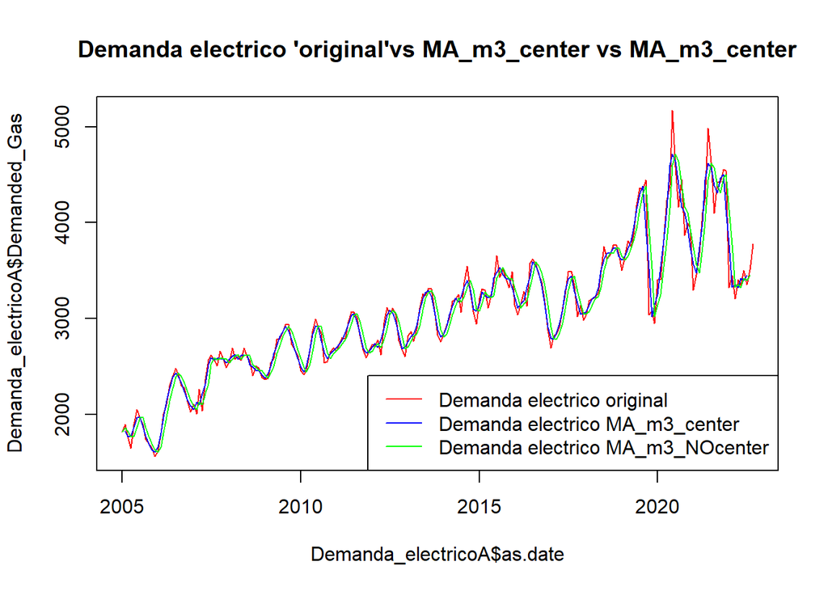

```r
plot(x=Demanda_electricoA$as.date, y=Demanda_electricoA$Demanded_Gas, col = "red", main = "Demanda electrico 'original'vs MA_m3_center vs MA_m3_center", type="l")
lines(x=Demanda_electricoA$as.date, y=Demanda_electricoA$Demand_MA3_Center, col="blue")
lines(x=Demanda_electricoA$as.date, y=Demanda_electricoA$Demand_MA3_NOCenter, col="green")
legend("bottomright", legend = c("Demanda electrico original", "Demanda electrico MA_m3_center", "Demanda electrico MA_m3_NOcenter"), col = c("red", "blue", "green"), lty = 1)
```

```r
library(forecast)
WMA_m4 <- WMA(Demanda_electricoA.ts, n=4, wts=c(0.2,0.1,0.3,0.4))
WMA_m4
```

```
##           Jan      Feb      Mar      Apr      May      Jun      Jul      Aug
## 2005       NA       NA       NA 1740.287 1806.678 1906.792 1918.430 1928.759
## 2006 1616.553 1691.555 1817.892 1948.111 2114.007 2261.429 2363.464 2409.086
## 2007 2119.557 2064.859 2121.732 2114.805 2182.962 2390.888 2461.040 2546.347
## 2008 2555.394 2606.788 2591.312 2591.922 2601.691 2619.881 2622.651 2585.861
## 2009 2409.845 2395.081 2441.035 2505.674 2617.641 2715.241 2777.702 2870.552
## 2010 2580.064 2499.142 2476.961 2527.590 2668.007 2812.428 2879.635 2885.828
## 2011 2648.015 2695.402 2747.812 2762.661 2850.749 2958.328 3002.503 3026.486
## 2012 2685.910 2689.488 2729.195 2697.292 2787.921 2950.810 2969.190 3056.520
## 2013 2731.721 2789.658 2766.920 2836.807 2962.177 3078.997 3163.060 3246.267
## 2014 2860.968 2865.414 2914.481 3032.747 3121.459 3177.392 3156.707 3232.435
## 2015 3131.932 3197.035 3221.291 3206.762 3226.216 3289.863 3418.292 3457.099
## 2016 3320.232 3171.498 3183.695 3190.585 3159.329 3327.697 3487.945 3498.382
## 2017 2933.369 2854.939 2824.986 2836.797 2968.737 3096.332 3267.365 3393.269
## 2018 3028.643 3112.615 3138.268 3176.995 3232.593 3335.901 3515.880 3575.646
```

[output cut: 23 more lines]

```r
typeof(WMA_m4 )
```

```
## [1] "double"
```

```r
dim(WMA_m4 )
```

Intentemos transformar WMA_m4 a una con un placeholder

```r
WMA_m4_placeholder <- c(WMA_m4, NA)
WMA_m4_placeholder
```

```
##   [1]       NA       NA       NA 1740.287 1806.678 1906.792 1918.430 1928.759
##   [9] 1869.087 1781.474 1720.198 1636.489 1616.553 1691.555 1817.892 1948.111
##  [17] 2114.007 2261.429 2363.464 2409.086 2371.158 2336.543 2248.402 2137.804
##  [25] 2119.557 2064.859 2121.732 2114.805 2182.962 2390.888 2461.040 2546.347
##  [33] 2551.824 2596.566 2594.913 2536.237 2555.394 2606.788 2591.312 2591.922
##  [41] 2601.691 2619.881 2622.651 2585.861 2528.274 2498.865 2497.164 2429.793
##  [49] 2409.845 2395.081 2441.035 2505.674 2617.641 2715.241 2777.702 2870.552
##  [57] 2902.895 2843.442 2773.798 2711.803 2580.064 2499.142 2476.961 2527.590
##  [65] 2668.007 2812.428 2879.635 2885.828 2760.323 2651.072 2651.031 2635.912
##  [73] 2648.015 2695.402 2747.812 2762.661 2850.749 2958.328 3002.503 3026.486
##  [81] 2955.069 2829.741 2723.273 2675.173 2685.910 2689.488 2729.195 2697.292
##  [89] 2787.921 2950.810 2969.190 3056.520 3074.412 2935.626 2827.880 2729.773
##  [97] 2731.721 2789.658 2766.920 2836.807 2962.177 3078.997 3163.060 3246.267
## [105] 3292.523 3202.723 3047.637 2920.320 2860.968 2865.414 2914.481 3032.747
## [113] 3121.459 3177.392 3156.707 3232.435 3385.989 3327.725 3243.257 3135.947
## [121] 3131.932 3197.035 3221.291 3206.762 3226.216 3289.863 3418.292 3457.099
## [129] 3473.063 3496.236 3392.811 3438.021 3320.232 3171.498 3183.695 3190.585
## [137] 3159.329 3327.697 3487.945 3498.382 3535.415 3472.601 3343.159 3133.335
## [145] 2933.369 2854.939 2824.986 2836.797 2968.737 3096.332 3267.365 3393.269
## [153] 3383.306 3256.188 3191.635 3103.716 3028.643 3112.615 3138.268 3176.995
## [161] 3232.593 3335.901 3515.880 3575.646 3622.996 3717.867 3729.183 3711.676
## [169] 3633.318 3631.155 3702.654 3707.289 3786.033 3973.440 4137.964 4239.807
## [177] 4354.340 3855.312 3455.129 3294.620 3160.265 3291.762 3478.126 3860.631
## [185] 4088.163 4571.066 4669.118 4434.514 4521.628 4216.166 4037.302 4052.589
## [193] 3675.276 3564.553 3626.850 3751.425 3987.990 4414.133 4593.756 4376.418
## [201] 4459.690 4430.572 4410.398 4509.393 4029.205 3741.506 3557.577 3332.594
## [209] 3371.700 3386.225 3405.689 3427.735       NA
```

Agregando la data WMA_m4_placeholdera la tabla Demanda_electricoA como unanueva columna de nombre: Demanda_WMA_m4

```r
Demanda_electricoA$Demanda_WMA_m4 <- WMA_m4_placeholder
head(Demanda_electricoA$Demand_WMA_m4r)
```

```r
head(Demanda_electricoA)
```

```
##       Date Demanded_Gas    as.date Demand_MA3_Center Demand_MA3_NOCenter
## 1 1/1/2005      1819.58 2005-01-01                NA            1819.580
## 2 2/1/2005      1895.33 2005-02-01          1826.923            1857.455
## 3 3/1/2005      1765.86 2005-03-01          1767.963            1826.923
## 4 4/1/2005      1642.70 2005-04-01          1768.033            1767.963
## 5 5/1/2005      1895.54 2005-05-01          1863.320            1768.033
## 6 6/1/2005      2051.72 2005-06-01          1969.770            1863.320
##   Demanda_WMA_m4
## 1             NA
## 2             NA
## 3             NA
## 4       1740.287
## 5       1806.678
## 6       1906.792
```

```r
typeof(Demanda_electricoA)
```

```
## [1] "list"
```

```r
dim(Demanda_electricoA)
```

```
## [1] 213   6
```

```r
tail(Demanda_electricoA)
```

```
##         Date Demanded_Gas    as.date Demand_MA3_Center Demand_MA3_NOCenter
## 208 4/1/2022      3403.44 2022-04-01          3320.143            3353.400
## 209 5/1/2022      3350.03 2022-05-01          3417.390            3320.143
## 210 6/1/2022      3498.70 2022-06-01          3399.900            3417.390
## 211 7/1/2022      3350.97 2022-07-01          3452.030            3399.900
## 212 8/1/2022      3506.42 2022-08-01                NA            3452.030
## 213 9/1/2022      3778.37 2022-09-01                NA                  NA
##     Demanda_WMA_m4
## 208       3332.594
## 209       3371.700
## 210       3386.225
## 211       3405.689
## 212       3427.735
## 213             NA
```

Vamos a plotear los vamores de “Demanda electrico original”, “Demanda electrico MA_m3_center”, “Demanda electrico MA_m3_NOcenter”, “Demanda electrico WA_ma”

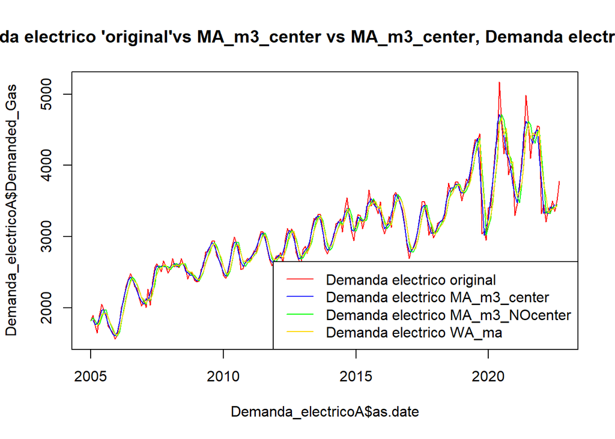

```r
plot(x=Demanda_electricoA$as.date, y=Demanda_electricoA$Demanded_Gas, col = "red", main = "Demanda electrico 'original'vs MA_m3_center vs MA_m3_center, Demanda electrico WA_ma", type="l")
lines(x=Demanda_electricoA$as.date, y=Demanda_electricoA$Demand_MA3_Center, col="blue")
lines(x=Demanda_electricoA$as.date, y=Demanda_electricoA$Demand_MA3_NOCenter, col="green")
lines(x=Demanda_electricoA$as.date, y=Demanda_electricoA$Demanda_WMA_m4, col="gold")
legend("bottomright", legend = c("Demanda electrico original", "Demanda electrico MA_m3_center", "Demanda electrico MA_m3_NOcenter", "Demanda electrico WA_ma"), col = c("red", "blue", "green", "gold"), lty = 1)
```

Revisando la mean & standard deviation of the different MOVING AVERAGE calculations

```r
print("Mean & sd of Demanded_Gas")
```

```
## [1] "Mean & sd of Demanded_Gas"
```

```r
mean(Demanda_electricoA$Demanded_Gas)
```

```
## [1] 3038.466
```

```r
sd(Demanda_electricoA$Demanded_Gas)
```

```
## [1] 677.9319
```

```r
print("Mean & sd of Demand_MA3_Center")
```

```
## [1] "Mean & sd of Demand_MA3_Center"
```

```r
mean(Demanda_electricoA$Demand_MA3_Center, na.rm = TRUE)
```

```
## [1] 3038.645
```

```r
sd(Demanda_electricoA$Demand_MA3_Center, na.rm = TRUE)
```

```
## [1] 657.1796
```

```r
print("Mean & sd of DDemand_MA3_NOCenter")
```

```
## [1] "Mean & sd of DDemand_MA3_NOCenter"
```

```r
mean(Demanda_electricoA$Demand_MA3_NOCenter, na.rm = TRUE)
```

```
## [1] 3027.323
```

```r
sd(Demanda_electricoA$Demand_MA3_NOCenter, na.rm = TRUE)
```

```
## [1] 664.3178
```

```r
print("Mean & sd of Demanda_WMA_m4")
```

```
## [1] "Mean & sd of Demanda_WMA_m4"
```

```r
mean(Demanda_electricoA$Demanda_WMA_m4, na.rm = TRUE)
```

```
## [1] 3043.623
```

```r
sd(Demanda_electricoA$Demanda_WMA_m4, na.rm = TRUE)
```

```
## [1] 646.8589
```

Comparando los errores tipo MAPE entre los diferentes resultados que llevamos al momento

```r
print("MAPE de Demanda_electrico vs MA_3_CENTER" )
```

```
## [1] "MAPE de Demanda_electrico vs MA_3_CENTER"
```

```r
mape_Demanded_MA3_center <- mean(abs((Demanda_electricoA$Demanded_Gas - Demanda_electricoA$Demand_MA3_Center)/Demanda_electricoA$Demanded_Gas), na.rm = TRUE) * 100
mape_Demanded_MA3_center
```

```
## [1] 2.287383
```

```r
print("MAPE de Demanda_electrico vs MA_3_NOCENTER" )
```

```
## [1] "MAPE de Demanda_electrico vs MA_3_NOCENTER"
```

```r
mape_Demanded_MA3_NOcenter <- mean(abs((Demanda_electricoA$Demanded_Gas - Demanda_electricoA$Demand_MA3_NOCenter)/Demanda_electricoA$Demanded_Gas), na.rm = TRUE) * 100
mape_Demanded_MA3_NOcenter
```

```
## [1] 3.874389
```

```r
print("MAPE de Demanda_electrico vs WA_4" )
```

```
## [1] "MAPE de Demanda_electrico vs WA_4"
```

```r
mape_Demanded_WA4 <- mean(abs((Demanda_electricoA$Demanded_Gas - Demanda_electricoA$Demanda_WMA_m4)/Demanda_electricoA$Demanded_Gas), na.rm = TRUE) * 100
mape_Demanded_WA4
```

```
## [1] 3.788864
```